[figure not shown]

# Introducción a K-means

### Fundación Universitaria Konrad Lorenz

Viviana Márquez [vivianam.penam@konradlorenz.edu.co]

Julio 24, 2020

## 📝 Hoy veremos...

• K-means en el contexto de Machine Learning

• Cuándo usar K-means

• El paso a paso de K-means

[figure not shown]

• Ejercicio de programación

• Errores comunes y cuando NO usar K-means

• Cómo escoger la mejor K

• ¡Recapitulando!

• En la próxima clase...

• Laboratorio

## 🌎 K-means en el mundo de Machine Learning

[figure not shown]

## 🌎 K-means en el mundo de Machine Learning

[figure not shown]

## 🤖 Métodos de Agrupación

Es la forma más común de aprendizaje no supervisado

#### Datos

• Muestras de entrenamiento $\{ x_1, \ldots, x_n\} \in \mathbb{R}^{n}$

• No necesitamos *(tenemos)* etiquetas $y_i$

#### Sirve para detectar patrones

- Agrupar clientes para campañas de publicidad
- Recomendaciones de resultados de busqueda
- Segmentación de imagenes
- y más...

## Primera (?) aplicación de agrupación

[figure not shown]

• En la década de 1850, un médico de Londres llamado John Snow, graficó la ubicación de las muertes por cólera en un mapa.

• Las ubicaciones mostraron que los casos estaban agrupados cerca ciertas intersecciones donde habían pozos contaminados -- así, exponiendo tanto el problema como la solución.

[figure not shown]

Fuente: Nina Mishra HP Labs

## 🤖 Métodos de Agrupación

**Objetivo:** Agrupar ejemplares en clases de objetos similares-- "cúmulos/clusters"

**¿Cuándo usarlos?** Cuando no sabemos qué estamos buscando

**... pero, ¡cuidado, se puede convertir en galimatías!**

## 🌎 K-means en el mundo de Machine Learning

[figure not shown]

## 🔎 K-means en el mundo de Machine Learning

[figure not shown]

## 🔎 K-means en el mundo de Machine Learning

[figure not shown]

## 🔎 K-means en el mundo de Machine Learning

[figure not shown]

# K-means

**(También conocido como K-medias)**

Modelo de Machine Learning NO supervisado de agrupación por partición

[figure not shown]

K-means un algoritmo **iterativo** cuyo objetivo es particionar un conjunto de $N$ observaciones  
en $K$ grupos en el que cada observación pertenece al grupo cuyo valor medio es más cercano.

### K-means --- Pasos

[figure not shown]

**1. Inicializar**  
A. Elegir un número K de cúmulos  
B. Escoger aleatoriamente K puntos como centroides

[figure not shown]

**2. Repetir**  
A. Los K cúmulos se crean asociando cada observación con la media más cercana  
B. El nuevo centroide de cada uno de los K cúmulos es la media de sus observaciones

### K-means --- Pasos

[figure not shown]

**3. Parar**  
A. Repetir pasos 1 y 2  
B. El algoritmo acaba cuando ya no hay cambio en los centroides de los cúmulos, las observaciones de los cúmulos siguen siendo las mismas, o el máximo número de iteraciones es alcanzado

#### Referencias:

- Definición matemática: [Link](http://cs229.stanford.edu/notes/cs229-notes7a.pdf)
- Visualización: [Video](https://www.youtube.com/watch?v=BVFG7fd1H30)

### 👮‍♀️ Punto de control

[figure not shown]

¿Cuál es el número de $K$?

¿Qué está pasando en cada paso?

# 👩‍💻 Manos a la obra

### Problema

[figure not shown]

Tenemos que identificar tres distintas especies de la flor del género *iris* y sólo tenemos información sobre el tamaño de sus pétalos.

# 👩‍💻 Manos a la obra

**Paso 1:** Cargar los datos

```python
import pandas as pd
import seaborn as sns

iris = sns.load_dataset("iris")
iris = iris[['petal_length', 'petal_width']]

iris.sample(5)
```

|  | petal_length | petal_width |
| --- | --- | --- |
| 82 | 3.9 | 1.2 |
| 31 | 1.5 | 0.4 |
| 69 | 3.9 | 1.1 |
| 37 | 1.4 | 0.1 |
| 48 | 1.5 | 0.2 |

```python
iris.shape
```

```
(150, 2)
```

*Recordatorio:*  
Para cualquier modelo, al cargar los datos siempre debemos verificar que esten correctos, lidiar con los datos faltantes, escoger las características importantes, hacer ingeniería de características (feature engineering), etc.

# 👩‍💻 Manos a la obra

**Paso 2:** Entrenar el modelo

```python
from sklearn.cluster import KMeans # 🙏our savior

model = KMeans(n_clusters=3)
model.fit(iris)
```

```
KMeans(algorithm='auto', copy_x=True, init='k-means++', max_iter=300,
       n_clusters=3, n_init=10, n_jobs=None, precompute_distances='auto',
       random_state=None, tol=0.0001, verbose=0)
```

¡Importante! Revisar los parametros disponibles en la [documentación](https://scikit-learn.org/stable/modules/generated/sklearn.cluster.KMeans.html).

# 👩‍💻 Trabajando con el modelo

```python
# Los resultados
model.labels_
```

```
array([0, 0, 0, 0, 0, 0, 0, 0, 0, 0, 0, 0, 0, 0, 0, 0, 0, 0, 0, 0, 0, 0,
       0, 0, 0, 0, 0, 0, 0, 0, 0, 0, 0, 0, 0, 0, 0, 0, 0, 0, 0, 0, 0, 0,
       0, 0, 0, 0, 0, 0, 2, 2, 2, 2, 2, 2, 2, 2, 2, 2, 2, 2, 2, 2, 2, 2,
       2, 2, 2, 2, 2, 2, 2, 2, 2, 2, 2, 1, 2, 2, 2, 2, 2, 1, 2, 2, 2, 2,
       2, 2, 2, 2, 2, 2, 2, 2, 2, 2, 2, 2, 1, 1, 1, 1, 1, 1, 2, 1, 1, 1,
       1, 1, 1, 1, 1, 1, 1, 1, 1, 2, 1, 1, 1, 1, 1, 1, 2, 1, 1, 1, 1, 1,
       1, 1, 1, 1, 1, 1, 2, 1, 1, 1, 1, 1, 1, 1, 1, 1, 1, 1], dtype=int32)
```

```python
iris['cluster'] = model.labels_
iris.sample(5)
```

|  | petal_length | petal_width | cluster |
| --- | --- | --- | --- |
| 18 | 1.7 | 0.3 | 0 |
| 6 | 1.4 | 0.3 | 0 |
| 41 | 1.3 | 0.3 | 0 |
| 14 | 1.2 | 0.2 | 0 |
| 117 | 6.7 | 2.2 | 1 |

```python
iris.cluster.value_counts()
```

```
2    52
0    50
1    48
Name: cluster, dtype: int64
```

# 👩‍💻 Trabajando con el modelo

```python
# Centroides
model.cluster_centers_
```

```
array([[1.462     , 0.246     ],
       [5.59583333, 2.0375    ],
       [4.26923077, 1.34230769]])
```

```python
df_centroides = pd.DataFrame(model.cluster_centers_)
df_centroides.columns = ['petal_length', 'petal_width']
df_centroides['cluster'] = [0,1,2]
df_centroides
```

|  | petal_length | petal_width | cluster |
| --- | --- | --- | --- |
| 0 | 1.462000 | 0.246000 | 0 |
| 1 | 5.595833 | 2.037500 | 1 |
| 2 | 4.269231 | 1.342308 | 2 |

# 👩‍💻 Visualizar el modelo

```python
def plot(r=False):
    if r == True:
        t = [f"Largo: {largo:.2f}cm<br>Ancho: {ancho:.2f}<br>Cluster: {c} - {r}" for largo,ancho,c,r in zip(iris.petal_length, iris.petal_width.values, iris.cluster.values, sns.load_dataset("iris").species.values)]
    else:
        t = [f"Largo: {largo:.2f}cm<br>Ancho: {ancho:.2f}<br>Cluster: {c}" for largo,ancho,c in zip(iris.petal_length, iris.petal_width.values, iris.cluster.values)]


    colors = {0: 'green', 1: 'red', 2: 'orange'}

    # Traza de los ejemplares
    traza_ejemplares = go.Scatter(

        x=iris.petal_length.values,
        y=iris.petal_width.values,
        text = t,
        hoverinfo='text',
        mode='markers',
        marker = {'color': [colors[c] for c in iris.cluster.values]},
        name="Observaciones"
    )


    # Traza de los centroides
    traza_centroides = go.Scatter(

        x=df_centroides.petal_length.values,
        y=df_centroides.petal_width.values,
        text = [f"CENTROIDE<br>Largo: {largo:.2f}cm<br>Ancho: {ancho:.2f}<br>Cluster: {c}" for largo,ancho,c in zip(iris.petal_length, iris.petal_width.values, iris.cluster.values)],
        hoverinfo='text',
        mode='markers',
        marker = {'color': [colors[c] for c in df_centroides.cluster.values],
                   'line': dict(color='yellow', width=1),
                  'symbol': 202,
                  'size': 10},
        name="Centroides",
    )


    # Layout
    layout = go.Layout(title="Iris Clustering",
                       xaxis_title="Largo del Pétalo",
                       yaxis_title="Ancho del Pétalo")

    # Figura
    fig = go.Figure(data=[traza_ejemplares, traza_centroides], layout=layout)
    iplot(fig)
```

```python
plot()
```

[interactive chart not shown]

```python
# ¿Lo hizo bien?
sns.load_dataset("iris").species.values[:10]
```

```
array(['setosa', 'setosa', 'setosa', 'setosa', 'setosa', 'setosa',
       'setosa', 'setosa', 'setosa', 'setosa'], dtype=object)
```

```python
model.predict([[1,0.5]])
```

```
array([0], dtype=int32)
```

# 📞 Llamada a la realidad

[figure not shown]

• Dominio del tema es importante

• Escoger, limpiar, transformar y crear nuevas variables dependientes

• No se puede visualizar en muchas dimensiones

• En un contexto de negocios, quizás es mejor usar `sklearn_extra.cluster.KMedoids`

**Atención**: Si las variables son discretas, toca cambiar la métrica (función distancia)

# 🙁 ¿Qué puede salir mal?

Desventajas de K-means

• Se tiene que escoger K con antelación (más de eso adelante)

• Es intensivo computacionalmente

• Cada observación pertenece a un sólo cúmulo

• Sensible a las observaciones atípicas

• No puede modelar relaciones complejas

# 🙁 ¿Qué puede salir mal?

Cuando NO usar K-means

[figure not shown]

# 🙁 ¿Qué puede salir mal?

Cuando NO usar K-means

[figure not shown]

# 🙁 ¿Qué puede salir mal?

Cuando NO usar K-means

[figure not shown]

# ¿Cómo escoger K?

#### Es importante escoger un buen número para K

[figure not shown]

# ¿Cómo escoger K?

#### ¿Cuántos cúmulos hay aquí?

[figure not shown]

# ¿Cómo escoger K?

#### ¿Cuántos cúmulos hay aquí?

#### ¿Dos?

[figure not shown]

# ¿Cómo escoger K?

#### ¿Cuántos cúmulos hay aquí?

#### ¿Ocho?

[figure not shown]

### 👮‍♀️ Punto de control

• ¿Cuál es valor mínimo posible para K?

• ¿Cuál es valor máximo para K?

• ¿Cómo escoger el número óptimo para K?

# ¿Cómo escoger K?

#### Método #1: El método del codo

```python
# Inercia: Suma de la distancia de las observaciones a su centroide más cercano
model.inertia_
```

```
31.371358974358973
```

```python
inercias = {}

for k in range(1, 10):
    kmeans = KMeans(n_clusters=k).fit(iris[['petal_length', 'petal_width']])
    inercias[k] = kmeans.inertia_
```

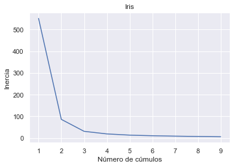

```python
plt.plot(list(inercias.keys()), list(inercias.values()))
plt.xlabel("Número de cúmulos"); plt.ylabel("Inercia"); plt.title('Iris');
```

# Recapitulando

[figure not shown]

• Los modelos de agrupación son técnicas no supervisadas de Machine Learning que buscan extraer la estructura de los datos al juntar las observaciones similares.

• K-means es el modelo de agrupación más usado

• El algoritmo es iterativo y reasigna los centroides hasta cuando ya no haya cambio en los grupos

• Como todo modelo, es importante hacer una buena selección de variables dependientes y usar conocimento del tema para evaluar e interpretar el modelo.

• Hay que considerar las limitaciones del modelo a la hora de escoger trabajar o no con él.

# 🤔 En la próxima clase...

Más algoritmos de agrupación

[figure not shown]

Lectura adicional: [Documentación](https://scikit-learn.org/stable/modules/clustering.html)

# 🤓 Laboratorio

• Datos más complejos

• Método de la silueta

• Portafolio